# STAT 5361 - Homework 2

Jin Xu

08 February 2018

### Problem 1

#### Problem 1(a)

log-likelihood function: $l(\theta) = \ln({\sum_{i=1}^{n}\dfrac{1}{\pi[1 + (x - \theta)^2]}}) = -n\ln{\pi} - \sum_{i=1}^{n} \ln{[1 + (x - \theta)^2]}$

1st derivative of log-likelihood function: $l'(\theta) = -2 \sum_{i=1}^{n} \dfrac{\theta - x_i}{1 + (x - \theta)^2}$

2nd derivative of log-likelihood function: $l''(\theta) = -2 \sum_{i=1}^{n} \dfrac{1 - (\theta - x_i)^2}{[1 + (x - \theta)^2]^2}$

fisher information: $p'(x) = \dfrac{2\pi(\theta - x)}{(\pi + \pi(x - \theta)^2)^2}$

$\dfrac{\{p'(x)\}^2}{p(x)} = 2(\theta-x)/{(1 + (x - \theta)^2)}$

$I(\theta) = n \int \dfrac{\{p'(x)\}^2}{p(x)}dx = \dfrac{4n}{\pi} \int_{-\infty}^{\infty} \dfrac{x^2 dx}{(1 + x^2)^3} = \dfrac{n}{2}$

#### Problem 1(b)

The graph of the log-likelihood function of $\theta$ is plotted from $[-50,50]$.

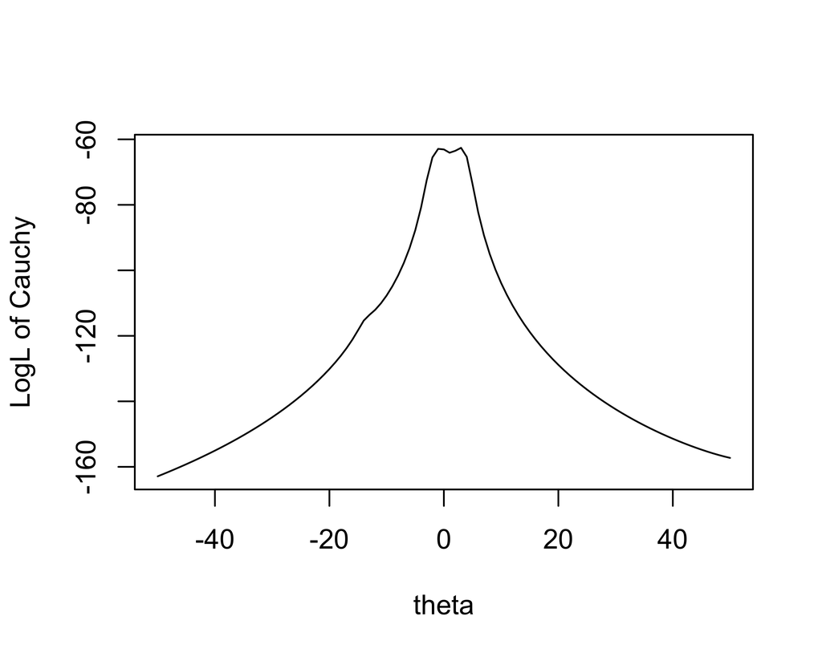

Log-likelihood function

Find the MLE for $\theta$ using the Newton-Raphson method

```
## when the starting point is -11, the MLE for theta is -5.079805e+13
```

```
## when the starting point is -1, the MLE for theta is -0.5914735
```

```
## when the starting point is 0, the MLE for theta is -0.5914735
```

```
## when the starting point is -1.5, the MLE for theta is 1.09273
```

```
## when the starting point is 4, the MLE for theta is 3.021345
```

```
## when the starting point is 4.7, the MLE for theta is -0.5914735
```

```
## when the starting point is 7, the MLE for theta is 4.239458e+13
```

```
## when the starting point is 8, the MLE for theta is 4.487811e+13
```

```
## when the starting point is 38, the MLE for theta is 3.938691e+13
```

```
## when the starting point is  3.257778 the MLE for theta is  3.021345
```

```
## [1] "The sample mean is a good starting point."
```

#### Problem 1(c)

Apply fixed-point iterations to find the MLE

```
## when the starting point is -11, alpha is 1, the MLE for theta is -0.5914784
```

```
## when the starting point is -1, alpha is 1, the MLE for theta is NA
```

```
## when the starting point is 0, alpha is 1, the MLE for theta is NA
```

```
## when the starting point is 1.5, alpha is 1, the MLE for theta is NA
```

```
## when the starting point is 4, alpha is 1, the MLE for theta is NA
```

```
## when the starting point is 4.7, alpha is 1, the MLE for theta is NA
```

```
## when the starting point is 7, alpha is 1, the MLE for theta is NA
```

```
## when the starting point is 8, alpha is 1, the MLE for theta is NA
```

```
## when the starting point is 38, alpha is 1, the MLE for theta is NA
```

```
## when the starting point is -11, alpha is 0.64, the MLE for theta is -0.5914741
```

```
## when the starting point is -1, alpha is 0.64, the MLE for theta is -0.591474
```

```
## when the starting point is 0, alpha is 0.64, the MLE for theta is -0.5914754
```

```
## when the starting point is 1.5, alpha is 0.64, the MLE for theta is NA
```

```
## when the starting point is 4, alpha is 0.64, the MLE for theta is -0.5914751
```

```
## when the starting point is 4.7, alpha is 0.64, the MLE for theta is -0.5914744
```

```
## when the starting point is 7, alpha is 0.64, the MLE for theta is NA
```

```
## when the starting point is 8, alpha is 0.64, the MLE for theta is -0.5914744
```

```
## when the starting point is 38, alpha is 0.64, the MLE for theta is NA
```

```
## when the starting point is -11, alpha is 0.25, the MLE for theta is -0.5914805
```

```
## when the starting point is -1, alpha is 0.25, the MLE for theta is -0.5914819
```

```
## when the starting point is 0, alpha is 0.25, the MLE for theta is -0.5914665
```

```
## when the starting point is 1.5, alpha is 0.25, the MLE for theta is 3.021345
```

```
## when the starting point is 4, alpha is 0.25, the MLE for theta is 3.021345
```

```
## when the starting point is 4.7, alpha is 0.25, the MLE for theta is 3.021345
```

```
## when the starting point is 7, alpha is 0.25, the MLE for theta is 3.021345
```

```
## when the starting point is 8, alpha is 0.25, the MLE for theta is 3.021345
```

```
## when the starting point is 38, alpha is 0.25, the MLE for theta is 3.021345
```

#### Problem 1(d)

Apply fisher scoring to find the MLE. The MLE coverges to either $-0.5914$ or $3.0213$.

```
## when the starting point is -11, the MLE for theta is -0.5915031
```

```
## when the starting point is -1, the MLE for theta is -0.5915022
```

```
## when the starting point is 0, the MLE for theta is -0.5914394
```

```
## when the starting point is -1.5, the MLE for theta is 3.021336
```

```
## when the starting point is 4, the MLE for theta is 3.021354
```

```
## when the starting point is 4.7, the MLE for theta is 3.021359
```

```
## when the starting point is 7, the MLE for theta is 3.021358
```

```
## when the starting point is 8, the MLE for theta is 3.021356
```

```
## when the starting point is 38, the MLE for theta is 3.021357
```

#### Problem 1(e)

Fisher scoring and Newton’s method both have the same asymptotic properties, but for individual problems one may be computationally or analytically easier than the other. Generally, Fisher scoring works better in the beginning to make rapid improvements, while Newton’s method works better for refinement near the end.

Since many log likelihoods are approximately locally quadratic, scaled fixed-point iteration can be a very effective tool. The method is also generally quite stable and easy to code.

### Problem 2

#### Problem 2(a)

log-likelihood function: $l(\theta) = \ln({\sum_{i=1}^{n}\dfrac{1-cos(x-\theta)}{2\pi}}) = -n\ln{2\pi} + \sum_{i=1}^{n} \ln{[1-cos(x-\theta)]}$ The graph of the log-likelihood function of $\theta$ is plotted from $[-\pi,\pi]$

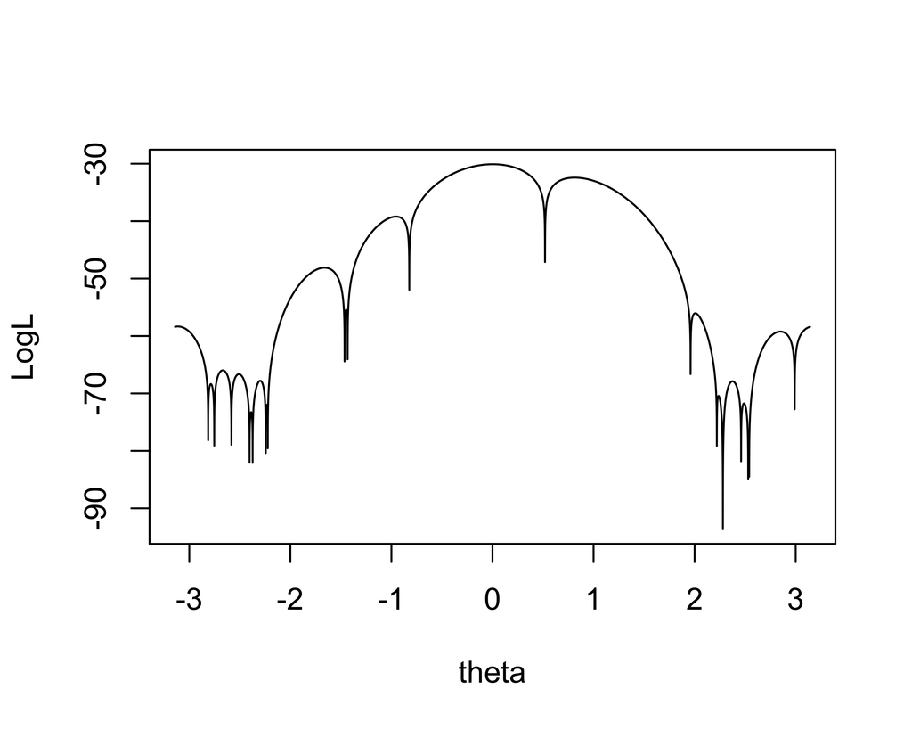

Log-likelihood function

#### Problem 2(b)

$\mathbb{E}[X | \theta] = \int_{0}^{2\pi} x p(x;\theta) dx = \dfrac{1}{2\pi}[\int_{0}^{2\pi}x dx - \int_{0}^{2\pi}xcos(x -\theta)] dx = \dfrac{1}{2\pi}[\dfrac{x^2}{2}\big|_{0}^{2\pi} - x sin(x - \theta)\big|_{0}^{2\pi} + \int_{0}^{2\pi} sin(x-\theta) dx] = \pi - sin\theta$

$\pi - sin\theta = 3.236842$

$\theta_0 = \hat{\theta}_{\text{moment}} = \arcsin(\pi - \bar{x})$

The method of moments of $\theta$ is -0.095394

#### Problem 2(c)(d)

```
## when the starting point is -0.095394, the MLE for theta is 0.003118157
```

```
## when the starting point is -2.7, the MLE for theta is -2.668857
```

```
## when the starting point is 2.7, the MLE for theta is 2.848415
```

#### Problem 2(e)

```
##  [1] -3.112471 -2.786557 -2.668857 -2.509356 -2.388267 -2.297926 -2.232192
##  [8] -1.662712 -1.447503 -0.954406  0.003118  0.812637  2.007223  2.237013
## [15]  2.374712  2.488450  2.848415  3.170715
```

### Problem 3

#### Problem 3(a)

1. Fit the population growth model

According to the sample population, K is around 1100

the starting value of r is determined by $\ln(1024/2)/154 = 0.04$

```r
beetles <- data.frame(
  days = c(0, 8, 28, 41, 63, 69, 97, 117, 135, 154),
  N_obv = c(2, 47, 192, 256, 768, 896, 1120, 896, 1184, 1024))
# set starting value
formula <- formula(N_obv~(K*N0)/(N0 + (K - N0) * exp(-r*days)))
K_start <- 1100
r_start <- 0.04
N0_start <- 2
# use nls model
m <- nls(formula, data = beetles,
         start=list(K=K_start, r = r_start, N0 = N0_start))
coef(summary(m), start)
```

```
##        Estimate Std. Error   t value     Pr(>|t|)
## K  1063.7048847 47.7780479 22.263465 9.325567e-08
## r     0.0866457  0.0186019  4.657894 2.320241e-03
## N0   12.1386279 11.7862190  1.029900 3.373225e-01
```

#### Problem 3(b)

contour plot of the sum of squares errors

sum of squared errors: $\varepsilon = \sum_{i=1}^{n} (N_i-f(t_i;K,r))^2 = \sum_{i=1}^{n} (N_i-f(K,r))^2$

The contour plot of SSE

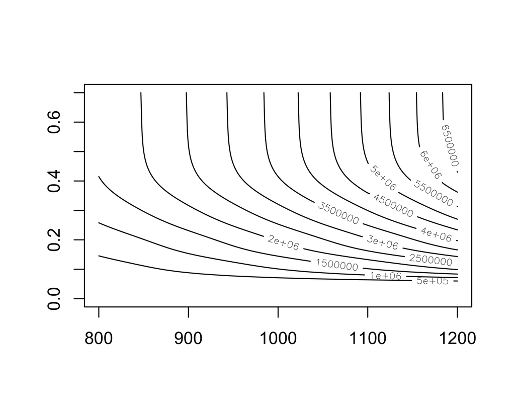

Contour Plot